# Modeling and prediction for movies with Bayesian Regression Modeling

Yoshie Toriya

04/09/2021

## Introduction

I am new as a data scientist at Paramount Pictures and my boss has acquired a dataset with which she expects me to present what attributes make a movie popular and how we can predict the popularity of the upcoming streaming release of movies. THe data includes information from Rotten Tomatoes and IMDB for a random sample of movies.

### Load packages and data

Let’s load the packages

```r
library(statsr)
library(rlang)
library(dplyr)
library(ggplot2)
library(BAS)
library(GGally)
library(gridExtra)
library(tidyr)
```

and data

```r
load("movies.Rdata")
```

that consists of 651 observations and 32 variables:

```r
str(movies)
```

```
## tibble[,32] [651 × 32] (S3: tbl_df/tbl/data.frame)
##  $ title           : chr [1:651] "Filly Brown" "The Dish" "Waiting for Guffman" "The Age of Innocence" ...
##  $ title_type      : Factor w/ 3 levels "Documentary",..: 2 2 2 2 2 1 2 2 1 2 ...
##  $ genre           : Factor w/ 11 levels "Action & Adventure",..: 6 6 4 6 7 5 6 6 5 6 ...
##  $ runtime         : num [1:651] 80 101 84 139 90 78 142 93 88 119 ...
##  $ mpaa_rating     : Factor w/ 6 levels "G","NC-17","PG",..: 5 4 5 3 5 6 4 5 6 6 ...
##  $ studio          : Factor w/ 211 levels "20th Century Fox",..: 91 202 167 34 13 163 147 118 88 84 ...
##  $ thtr_rel_year   : num [1:651] 2013 2001 1996 1993 2004 ...
##  $ thtr_rel_month  : num [1:651] 4 3 8 10 9 1 1 11 9 3 ...
##  $ thtr_rel_day    : num [1:651] 19 14 21 1 10 15 1 8 7 2 ...
##  $ dvd_rel_year    : num [1:651] 2013 2001 2001 2001 2005 ...
##  $ dvd_rel_month   : num [1:651] 7 8 8 11 4 4 2 3 1 8 ...
##  $ dvd_rel_day     : num [1:651] 30 28 21 6 19 20 18 2 21 14 ...
##  $ imdb_rating     : num [1:651] 5.5 7.3 7.6 7.2 5.1 7.8 7.2 5.5 7.5 6.6 ...
##  $ imdb_num_votes  : int [1:651] 899 12285 22381 35096 2386 333 5016 2272 880 12496 ...
```

[output cut: 18 more lines]

## Research question

Question for this analysis is, what is the best model to predict audience score and what attributes should it include?  
Note as it has been specified to develop a Bayesian regression model to predict `audience_score` from the following explanatory variables: `feature_film`,`drama`, `runtime`, `mpaa_rating_R`, `thtr_rel_year`, `oscar_season`, `summer_season`, `imdb_rating`, `imdb_num_votes`, `critics_score`, `best_pic_nom`, `best_pic_win`, `best_actor_win`, `best_actress_win`, `best_dir_win`, `top200_box`.

## Part 1: Data collection & Generalizability/Causality

We are provided with the information that “This dataset includes information from Rotten Tomatoes and IMDB for a random sample of movies” regarding the collection of the data. So based on it being “a random sample”, we could say the results of the analysis could be generalizable. It might also sound otherwise by mentioning Rotten Tomatoes and IMDB, but it does NOT say the data collection was “limited” from their users but merely “included” them, so with no further information I would not deny the generalizability. Causality, however, can be denied as the data collection does not involve random assignment.

## Part 2: Data manipulation

The following variables are not in the provided dataset, so need to be created:

```r
movies <- movies %>%
 mutate(feature_film = if_else(title_type == "Feature Film", "yes", "no"))
movies <- movies %>%
 mutate(drama = if_else(genre == "Drama", "yes", "no"))
movies <- movies %>%
 mutate(mpaa_rating_R = if_else(mpaa_rating == "R", "yes", "no") )
movies <- movies %>%
 mutate(oscar_season = if_else((thtr_rel_month >= 10 & thtr_rel_month <= 12), "yes", "no"))
movies <- movies %>%
 mutate(summer_season = if_else((thtr_rel_month >= 5 & thtr_rel_month <= 8), "yes", "no"))
```

## Part 3: Exploratory data analysis

This EDA is aimed to answer the “what attributes should the prediction modeling include?” part of the research question.

First I want to understand the year variable.

```r
mov_count <- movies %>%
  select(thtr_rel_year, title) %>%
  group_by(thtr_rel_year) %>%
  summarise(count = n())
```

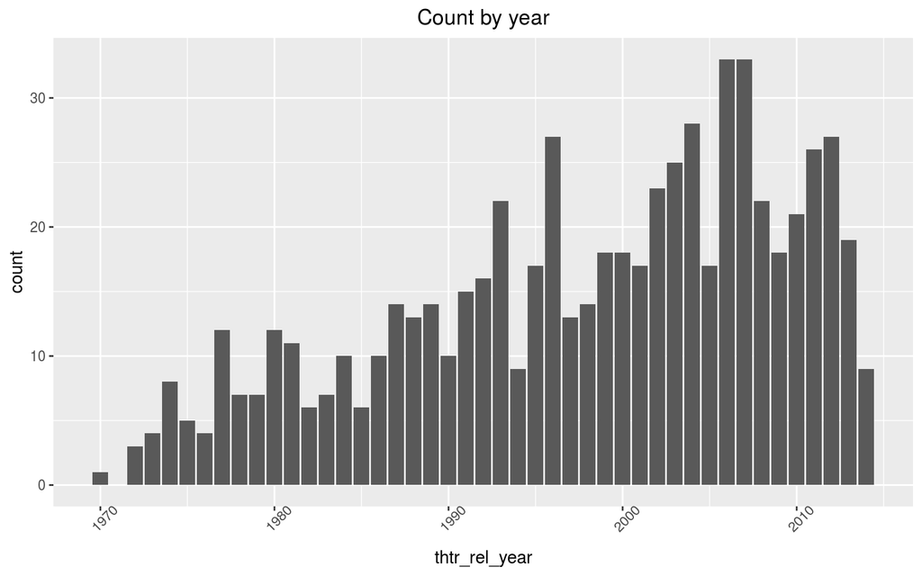

```r
ggplot(mov_count, aes(x=thtr_rel_year, y=count)) +
  geom_histogram(stat="identity") +
  theme(axis.text.x = element_text(angle = 45)) +
  ggtitle("Count by year") +
  theme(plot.title = element_text(hjust = 0.5))
```

The dataset covers movies with the release year ranged from 1970 to 2014.

Looking at the years, I was curious whether the gap between the year of the release and that of the score provided (in other words, how later the movie was scored after its release) might be an influential factor. But, as that is unknown, I checked whether there’s any association between the year of release and the score given (using `audience_score`):

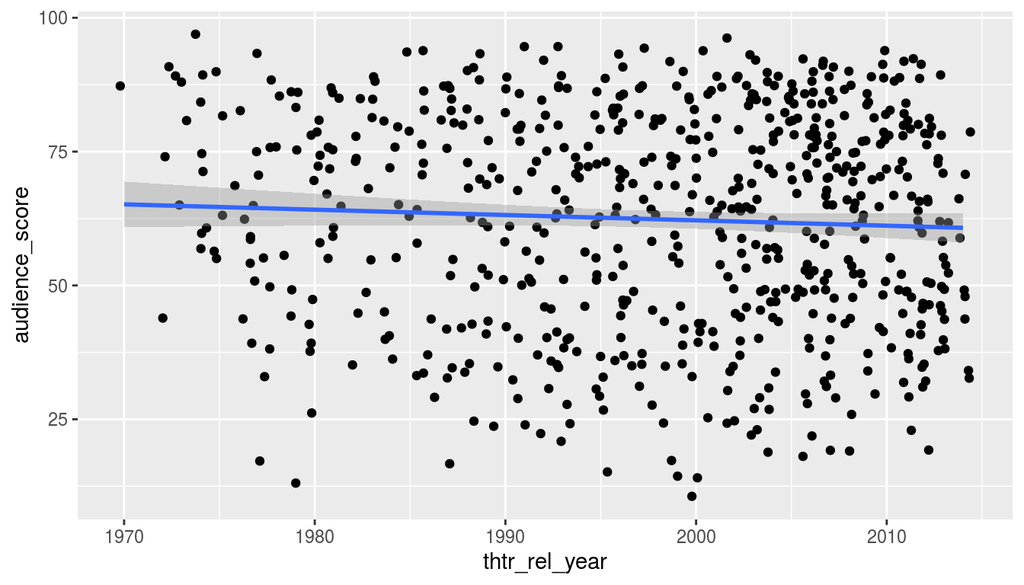

```r
ggplot(data = movies, aes(x = thtr_rel_year, y = audience_score)) +
  geom_jitter() +
  geom_smooth(method = "lm")
```

The measurement as below, as well as the visualization above, does not support the idea of association.

```r
corr_01 = lm(audience_score ~ thtr_rel_year, data = movies)
summary(corr_01)
```

```
##
## Call:
## lm(formula = audience_score ~ thtr_rel_year, data = movies)
##
## Residuals:
##     Min      1Q  Median      3Q     Max
## -51.250 -15.962   3.042  17.147  34.042
##
## Coefficients:
##                Estimate Std. Error t value Pr(>|t|)
## (Intercept)   261.45858  144.30579   1.812   0.0705 .
## thtr_rel_year  -0.09965    0.07223  -1.380   0.1682
## ---
## Signif. codes:  0 '***' 0.001 '**' 0.01 '*' 0.05 '.' 0.1 ' ' 1
##
## Residual standard error: 20.21 on 649 degrees of freedom
## Multiple R-squared:  0.002925,   Adjusted R-squared:  0.001388
## F-statistic: 1.904 on 1 and 649 DF,  p-value: 0.1682
```

Next, I want to look into the seemingly similar score/rating variables such as `critics_score` or `imdb_rating`, whether there is association with `audience score`. First, with `critics_score`:

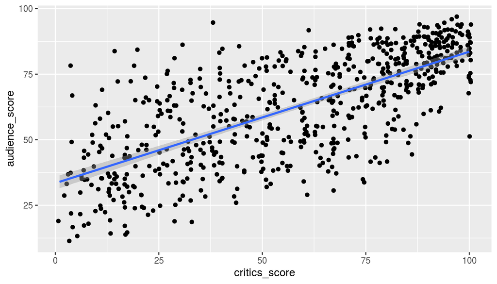

```r
ggplot(data = movies, aes(x = critics_score, y = audience_score)) +
  geom_jitter() +
  geom_smooth(method = "lm")
```

```r
corr_02 = lm(audience_score ~ critics_score, data = movies)
summary(corr_02)
```

```
##
## Call:
## lm(formula = audience_score ~ critics_score, data = movies)
##
## Residuals:
##     Min      1Q  Median      3Q     Max
## -37.043  -9.571   0.504  10.422  43.544
##
## Coefficients:
##               Estimate Std. Error t value Pr(>|t|)
## (Intercept)   33.43551    1.27561   26.21   <2e-16 ***
## critics_score  0.50144    0.01984   25.27   <2e-16 ***
## ---
## Signif. codes:  0 '***' 0.001 '**' 0.01 '*' 0.05 '.' 0.1 ' ' 1
##
## Residual standard error: 14.37 on 649 degrees of freedom
## Multiple R-squared:  0.496,  Adjusted R-squared:  0.4952
## F-statistic: 638.7 on 1 and 649 DF,  p-value: < 2.2e-16
```

It is showing strong association.

Next, with `imdb_rating`:

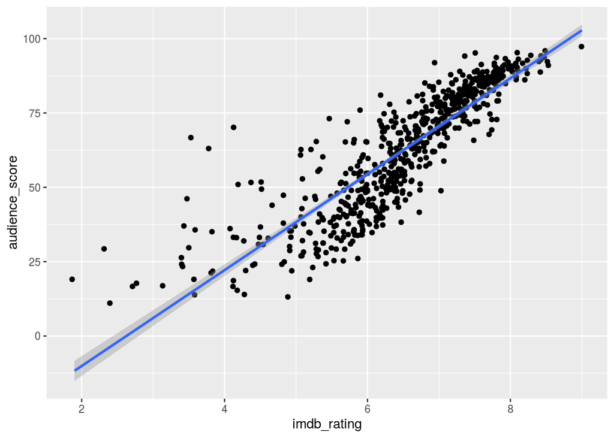

```r
ggplot(data = movies, aes(x = imdb_rating, y = audience_score)) +
  geom_jitter() +
  geom_smooth(method = "lm")
```

```r
corr_03 = lm(audience_score ~ imdb_rating, data = movies)
summary(corr_03)
```

```
##
## Call:
## lm(formula = audience_score ~ imdb_rating, data = movies)
##
## Residuals:
##     Min      1Q  Median      3Q     Max
## -26.800  -6.567   0.649   5.689  52.896
##
## Coefficients:
##             Estimate Std. Error t value Pr(>|t|)
## (Intercept) -42.3284     2.4183  -17.50   <2e-16 ***
## imdb_rating  16.1234     0.3674   43.89   <2e-16 ***
## ---
## Signif. codes:  0 '***' 0.001 '**' 0.01 '*' 0.05 '.' 0.1 ' ' 1
##
## Residual standard error: 10.16 on 649 degrees of freedom
## Multiple R-squared:  0.748,  Adjusted R-squared:  0.7476
## F-statistic:  1926 on 1 and 649 DF,  p-value: < 2.2e-16
```

There is strong association between `audience_score` and `imdb_rating`, and `critics_score`. As so learned in the past, these variables with strong association should not be included in the model. There is high potential they are influential to one another.  
Now let’s look into the newly constructed categorical variables:

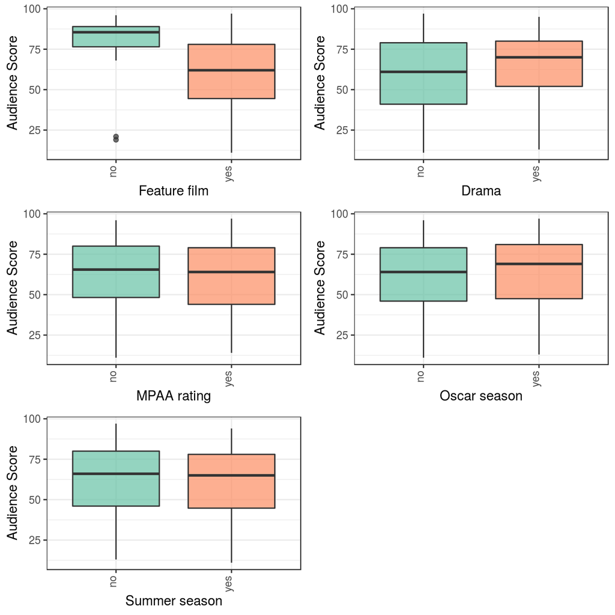

```r
p1 <- ggplot(movies, aes(x=feature_film, y = audience_score, fill = feature_film))+
  geom_boxplot(alpha = 0.7)+
  theme_bw()+
  labs(x = "Feature film", y= "Audience Score", fill = "feature_film")+
  theme(axis.text.x=element_text(angle=90, hjust = 1, vjust = 0))+
  theme(legend.position="none")+
  scale_fill_brewer(palette="Set2")
p2 <- ggplot(movies, aes(x=drama, y = audience_score, fill = drama))+
  geom_boxplot(alpha = 0.7)+
  theme_bw()+
  labs(x = "Drama", y= "Audience Score", fill = "drama")+
  theme(axis.text.x=element_text(angle=90, hjust = 1, vjust = 0))+
  theme(legend.position="none")+
  scale_fill_brewer(palette="Set2")
p3 <- ggplot(movies, aes(x=mpaa_rating_R, y = audience_score, fill = mpaa_rating_R))+
  geom_boxplot(alpha = 0.7)+
  theme_bw()+
  labs(x = "MPAA rating", y= "Audience Score", fill = "mpaa_rating_R")+
  theme(axis.text.x=element_text(angle=90, hjust = 1, vjust = 0))+
  theme(legend.position="none")+
  scale_fill_brewer(palette="Set2")
p4 <- ggplot(movies, aes(x=oscar_season, y = audience_score, fill = oscar_season))+
  geom_boxplot(alpha = 0.7)+
  theme_bw()+
  labs(x = "Oscar season", y= "Audience Score", fill = "mpaa_rating_R")+
  theme(axis.text.x=element_text(angle=90, hjust = 1, vjust = 0))+
  theme(legend.position="none")+
  scale_fill_brewer(palette="Set2")
p5 <- ggplot(movies, aes(x=summer_season, y = audience_score, fill = summer_season))+
  geom_boxplot(alpha = 0.7)+
  theme_bw()+
  labs(x = "Summer season", y= "Audience Score", fill = "summer_season")+
  theme(axis.text.x=element_text(angle=90, hjust = 1, vjust = 0))+
  theme(legend.position="none")+
  scale_fill_brewer(palette="Set2")
grid.arrange(p1, p2, p3, p4, p5, nrow = 3)
```

We can see clear difference between levels among ‘feature_film’ and ‘drama’.

Here is also one with the provided variables:

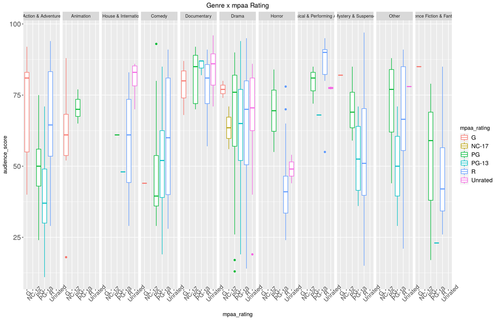

```r
ggplot(movies, aes(x = mpaa_rating, y = audience_score, color = mpaa_rating)) +
    geom_boxplot()+
  theme(axis.text.x = element_text(angle = 45, size = 12)) +
  theme(axis.text.y = element_text(size = 14)) +
  ggtitle("Genre x mpaa Rating") +
    facet_grid(.~genre)+
  theme(plot.title = element_text(hjust = 0.5)) +
  theme(legend.text = element_text(size = 12))
```

Now for the modeling, as mentioned earlier I will proceed with a reduced dataset without `imdb_rating`, `imdb_num_votes`, and `critics_score`.

```r
#dataset with 16 explanatory variables
movies_red <- movies %>%
        select(audience_score, feature_film, drama, runtime, mpaa_rating_R, thtr_rel_year, oscar_season, summer_season, best_pic_nom, best_pic_win, best_actor_win, best_actress_win, best_dir_win, top200_box)
```

before moving on, let’s see if any cleansing would be helpful - let’s check any in the selected variables:

```r
sapply(movies_red, function(x) sum(is.na(x)))
```

```
##   audience_score     feature_film            drama          runtime
##                0                0                0                1
##    mpaa_rating_R    thtr_rel_year     oscar_season    summer_season
##                0                0                0                0
##     best_pic_nom     best_pic_win   best_actor_win best_actress_win
##                0                0                0                0
##     best_dir_win       top200_box
##                0                0
```

that points `runtime` has NA.

```r
movies_red %>%
  select(runtime) %>%
  filter(is.na(runtime))
```

```
## # A tibble: 1 x 1
##   runtime
##     <dbl>
## 1      NA
```

since there is only 1 out of 651, I am going to remove the 1 observation

```r
movies_red <- movies_red %>%
  drop_na(runtime)
```

Here is the quick summary of the dataset that is going to be used for modeling:

```r
summary(movies_red)
```

```
##  audience_score  feature_film          drama              runtime
##  Min.   :11.00   Length:650         Length:650         Min.   : 39.0
##  1st Qu.:46.00   Class :character   Class :character   1st Qu.: 92.0
##  Median :65.00   Mode  :character   Mode  :character   Median :103.0
##  Mean   :62.35                                         Mean   :105.8
##  3rd Qu.:80.00                                         3rd Qu.:115.8
##  Max.   :97.00                                         Max.   :267.0
##  mpaa_rating_R      thtr_rel_year  oscar_season       summer_season
##  Length:650         Min.   :1970   Length:650         Length:650
##  Class :character   1st Qu.:1990   Class :character   Class :character
##  Mode  :character   Median :2000   Mode  :character   Mode  :character
##                     Mean   :1998
##                     3rd Qu.:2007
##                     Max.   :2014
##  best_pic_nom best_pic_win best_actor_win best_actress_win best_dir_win
##  no :628      no :643      no :557        no :578          no :607
##  yes: 22      yes:  7      yes: 93        yes: 72          yes: 43
##
##
##
##
##  top200_box
##  no :635
##  yes: 15
##
##
##
##
```

This EDA has answered the “what attributes should the predictive modeling include?” part of the research question, and we are now moving on to answer the “what is the best model to predict audience score” part.

## Part 4: Modeling

First, starting with the full model, using the bas.lim function and “BIC” that indicates the model is based on the non-informative reference prior:

```r
#run regression model
movies_red_bas = bas.lm(audience_score ~ ., data = movies_red, prior = "BIC", modelprior = Bernoulli(1), include.always = ~ ., n.models = 1)

#extract posterior parameters of coefficients
mv_rd.coef = coef(movies_red_bas)
mv_rd.coef
```

```
##
##  Marginal Posterior Summaries of Coefficients:
##
##  Using  BMA
##
##  Based on the top  1 models
##                      post mean  post SD    post p(B != 0)
## Intercept             62.34769    0.71016    1.00000
## feature_filmyes      -27.38634    2.64141    1.00000
## dramayes               7.66907    1.53198    1.00000
## runtime                0.12974    0.04187    1.00000
## mpaa_rating_Ryes       1.36528    1.46787    1.00000
## thtr_rel_year         -0.13388    0.06601    1.00000
## oscar_seasonyes       -0.47874    1.80871    1.00000
## summer_seasonyes       1.15661    1.71527    1.00000
## best_pic_nomyes       20.85953    4.66311    1.00000
## best_pic_winyes       -3.20089    8.24577    1.00000
## best_actor_winyes     -1.77560    2.13842    1.00000
## best_actress_winyes   -2.53071    2.36627    1.00000
## best_dir_winyes        4.47242    3.11733    1.00000
## top200_boxyes         11.46261    4.84233    1.00000
```

All values of post p(B != 0) being 1 in the above indicates that all variables are included in this model. Following is the distributions of coefficients,

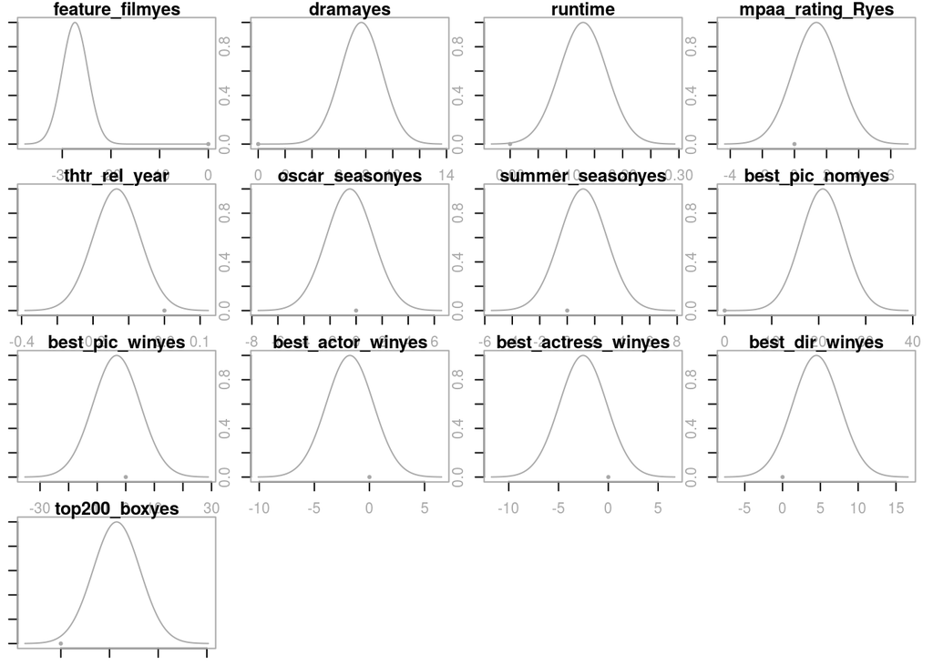

```r
par(mar = c(1,1,1,1), mfrow = c(4,4), col.lab = "darkgrey", col.axis = "darkgrey", col = "darkgrey")
plot(mv_rd.coef, subset = 2:14, ask = F)
```

which visualizes the following credible intervals:

```r
confint(mv_rd.coef, parm = 2:17)
```

```
##                             2.5%         97.5%        beta
## feature_filmyes     -32.57328002 -22.199405364 -27.3863427
## dramayes              4.66072627  10.677410085   7.6690682
## runtime               0.04751638   0.211972680   0.1297445
## mpaa_rating_Ryes     -1.51717909   4.247739200   1.3652801
## thtr_rel_year        -0.26349103  -0.004261281  -0.1338762
## oscar_seasonyes      -4.03049906   3.073016937  -0.4787411
## summer_seasonyes     -2.21166563   4.524880937   1.1566077
## best_pic_nomyes      11.70258264  30.016485831  20.8595342
## best_pic_winyes     -19.39312418  12.991340563  -3.2008918
## best_actor_winyes    -5.97482025   2.423628826  -1.7755957
## best_actress_winyes  -7.17735518   2.115929268  -2.5307130
## best_dir_winyes      -1.64907505  10.593922256   4.4724236
## top200_boxyes         1.95373115  20.971492706  11.4626119
## <NA>                          NA            NA          NA
## <NA>                          NA            NA          NA
## <NA>                          NA            NA          NA
## attr(,"Probability")
## [1] 0.95
## attr(,"class")
## [1] "confint.bas"
```

The following summarizes this model with the *posterior means*, *posterior standard deviation*, *lower* and *higher* points of the *credible interval*:

```r
#
out = confint(mv_rd.coef)[, 1:2]
#extract the uppper and lower bounds of the credible intervals
names = c("posterior mean", "posterior std", colnames(out))
out = cbind(mv_rd.coef$postmean, mv_rd.coef$postsd, out)
colnames(out) = names
round(out, 5)
```

```
##                     posterior mean posterior std      2.5%     97.5%
## Intercept                 62.34769       0.71016  60.95314  63.74224
## feature_filmyes          -27.38634       2.64141 -32.57328 -22.19941
## dramayes                   7.66907       1.53198   4.66073  10.67741
## runtime                    0.12974       0.04187   0.04752   0.21197
## mpaa_rating_Ryes           1.36528       1.46787  -1.51718   4.24774
## thtr_rel_year             -0.13388       0.06601  -0.26349  -0.00426
## oscar_seasonyes           -0.47874       1.80871  -4.03050   3.07302
## summer_seasonyes           1.15661       1.71527  -2.21167   4.52488
## best_pic_nomyes           20.85953       4.66311  11.70258  30.01649
## best_pic_winyes           -3.20089       8.24577 -19.39312  12.99134
## best_actor_winyes         -1.77560       2.13842  -5.97482   2.42363
## best_actress_winyes       -2.53071       2.36627  -7.17736   2.11593
## best_dir_winyes            4.47242       3.11733  -1.64908  10.59392
## top200_boxyes             11.46261       4.84233   1.95373  20.97149
```

Note that the later results will be compared to these values.

Next, we conduct the backward elimination with BIC, by starting with the full model and dropping one variable at a time to reach the smallest BIC with fewer predictors. (Note that AIC should read as BIC.)

```r
n = nrow(movies_red) # of observations
movies.lm = lm(audience_score ~ ., data = movies_red)
# BIC elimination
mv.step = step(movies.lm, k = log(n))
```

```
## Start:  AIC=3841.62
## audience_score ~ feature_film + drama + runtime + mpaa_rating_R +
##     thtr_rel_year + oscar_season + summer_season + best_pic_nom +
##     best_pic_win + best_actor_win + best_actress_win + best_dir_win +
##     top200_box
##
##                    Df Sum of Sq    RSS    AIC
## - oscar_season      1        23 208514 3835.2
## - best_pic_win      1        49 208540 3835.3
## - summer_season     1       149 208640 3835.6
## - best_actor_win    1       226 208717 3835.8
## - mpaa_rating_R     1       284 208775 3836.0
## - best_actress_win  1       375 208866 3836.3
## - best_dir_win      1       675 209166 3837.2
## - thtr_rel_year     1      1349 209839 3839.3
## - top200_box        1      1837 210328 3840.8
## <none>                          208491 3841.6
## - runtime           1      3147 211638 3844.9
## - best_pic_nom      1      6560 215051 3855.3
## - drama             1      8215 216706 3860.3
## - feature_film      1     35239 243730 3936.6
##
## Step:  AIC=3835.21
## audience_score ~ feature_film + drama + runtime + mpaa_rating_R +
##     thtr_rel_year + summer_season + best_pic_nom + best_pic_win +
##     best_actor_win + best_actress_win + best_dir_win + top200_box
##
##                    Df Sum of Sq    RSS    AIC
## - best_pic_win      1        47 208560 3828.9
## - best_actor_win    1       231 208745 3829.5
## - summer_season     1       254 208768 3829.5
## - mpaa_rating_R     1       284 208797 3829.6
## - best_actress_win  1       377 208890 3829.9
## - best_dir_win      1       664 209178 3830.8
## - thtr_rel_year     1      1341 209855 3832.9
## - top200_box        1      1818 210332 3834.4
## <none>                          208514 3835.2
## - runtime           1      3141 211655 3838.5
## - best_pic_nom      1      6553 215066 3848.8
## - drama             1      8275 216789 3854.0
```

[output cut: 104 more lines]

```
## <none>                      211858 3800.2
## - runtime       1      3634 215492 3804.8
## - best_pic_nom  1      7334 219192 3815.9
## - drama         1      8121 219979 3818.2
## - feature_film  1     34147 246005 3890.9
##
## Step:  AIC=3799.21
## audience_score ~ feature_film + drama + runtime + best_pic_nom
##
##                Df Sum of Sq    RSS    AIC
## <none>                      213648 3799.2
## - runtime       1      4358 218006 3805.9
## - drama         1      7648 221296 3815.6
## - best_pic_nom  1      7749 221397 3815.9
## - feature_film  1     33505 247153 3887.4
```

The last block marks the smallest BIC (labeled as AIC) with predictors `runtime`, `drama`, `best_pic_nom`, `feature_film`, and removing any of which will increase the BIC value.

Now for the diagnostic purpose, let’s look into the following:

- Marginal posterior inclusion probabilities and see the remaining predictors get much lower marginal posterior inclusion probabilities.

```r
#using bas.lm to run the model
mv.BIC = bas.lm(audience_score ~ ., data = movies_red, prior = "BIC", modelprior = uniform())
mv.BIC
```

```
##
## Call:
## bas.lm(formula = audience_score ~ ., data = movies_red, prior = "BIC",
##     modelprior = uniform())
##
##
##  Marginal Posterior Inclusion Probabilities:
##           Intercept      feature_filmyes             dramayes
##             1.00000              1.00000              0.99981
##             runtime     mpaa_rating_Ryes        thtr_rel_year
##             0.92081              0.05303              0.28669
##     oscar_seasonyes     summer_seasonyes      best_pic_nomyes
##             0.04257              0.05900              0.99959
##     best_pic_winyes    best_actor_winyes  best_actress_winyes
##             0.03868              0.05342              0.06440
##     best_dir_winyes        top200_boxyes
##             0.12626              0.38465
```

* List the predictors with the largest logmarg which also corresponds.

```r
#find the index of the model with the largest logmarg
best = which.max(mv.BIC$logmarg)
#retrieve the index of variables n the best model, with 0 as the index of the intercept
bestmodel = mv.BIC$which[[best]]
bestmodel
```

```
## [1] 0 1 2 3 8
```

* Using 1 to indicate the variable to include in the model

```r
#create an indicator vector indicating which variables are used in the best model
#first, create a 0 vector with the same dimension of the number of variables in the f
bestgamma = rep(0, mv.BIC$n.vars)
#Change the indicator to 1 when variables are used
bestgamma[bestmodel + 1] = 1
bestgamma
```

```
##  [1] 1 1 1 1 0 0 0 0 1 0 0 0 0 0
```

All the above agree on the predictors, `feature_film`, `drama`, `runtime`, and `best_pic_nom` for the best model.

Now we fit the best BIC model by imposing which variables to be used using the indicators

```r
mv.bestBIC = bas.lm(audience_score ~ ., data = movies_red, prior = "BIC", n.models = 1, bestmodel = bestgamma, modelprior = uniform())

#retrieve coefficients information
mvBIC.coef = coef(mv.bestBIC)

#retrieve bounds of credible intervals
out = confint(mvBIC.coef)[, 1:2]
#combine results and construct summary table
mvBICcoef.BIC = cbind(mvBIC.coef$postmean, mvBIC.coef$postsd, out)
names = c("post mean", "post sd", colnames(out))
colnames(mvBICcoef.BIC) = names
mvBICcoef.BIC
```

```
##                       post mean    post sd         2.5%       97.5%
## Intercept            62.3476923 0.71385977  60.94592249  63.7494621
## feature_filmyes     -25.9040573 2.57563156 -30.96169295 -20.8464217
## dramayes              7.2902254 1.51716706   4.31104229  10.2694086
## runtime               0.1420374 0.03916022   0.06514046   0.2189343
## mpaa_rating_Ryes      0.0000000 0.00000000   0.00000000   0.0000000
## thtr_rel_year         0.0000000 0.00000000   0.00000000   0.0000000
## oscar_seasonyes       0.0000000 0.00000000   0.00000000   0.0000000
## summer_seasonyes      0.0000000 0.00000000   0.00000000   0.0000000
## best_pic_nomyes      19.8429999 4.10259029  11.78695376  27.8990461
## best_pic_winyes       0.0000000 0.00000000   0.00000000   0.0000000
## best_actor_winyes     0.0000000 0.00000000   0.00000000   0.0000000
## best_actress_winyes   0.0000000 0.00000000   0.00000000   0.0000000
## best_dir_winyes       0.0000000 0.00000000   0.00000000   0.0000000
## top200_boxyes         0.0000000 0.00000000   0.00000000   0.0000000
```

All credible intervals of the four predictors became narrower compared to those in the full model we ran at first, meaning posterior standard deviations became smaller. It indicates that this is our parsimonious model based on BIC.

In addition to BIC and narrower intervals that are good indicators, note that we could miss out other similarly good models, thus we evaluate by other criteria such as the posterior probability and Bayers factor.

```r
mv_bas = bas.lm(audience_score ~ runtime + drama + best_pic_nom + feature_film, data = movies_red, prior = "BIC", modelprior = uniform())
round(summary(mv_bas), 3)
```

```
##                 P(B != 0 | Y)   model 1   model 2   model 3   model 4
## Intercept               1.000     1.000     1.000     1.000     1.000
## runtime                 0.965     1.000     0.000     1.000     1.000
## dramayes                1.000     1.000     1.000     0.000     1.000
## best_pic_nomyes         1.000     1.000     1.000     1.000     0.000
## feature_filmyes         1.000     1.000     1.000     1.000     1.000
## BF                         NA     1.000     0.036     0.000     0.000
## PostProbs                  NA     0.965     0.035     0.000     0.000
## R2                         NA     0.196     0.180     0.167     0.167
## dim                        NA     5.000     4.000     4.000     4.000
## logmarg                    NA -4004.620 -4007.944 -4012.812 -4012.960
##                   model 5
## Intercept           1.000
## runtime             0.000
## dramayes            0.000
## best_pic_nomyes     1.000
## feature_filmyes     1.000
## BF                  0.000
## PostProbs           0.000
## R2                  0.140
## dim                 3.000
## logmarg         -4020.046
```

Posterior probability puts the model 1 on the far top, from the model 2, and the remaining models on the bottom with value 0. Bayes factor indicates that model 1 is the one and only. Also note that feature_film be included in all top 5 models.

Here is also the marginal posterior inclusion probabilities, followed by log posterior odds:

```r
print(mv_bas) # obtain marginal posterior inclusion probability
```

```
##
## Call:
## bas.lm(formula = audience_score ~ runtime + drama + best_pic_nom +
##     feature_film, data = movies_red, prior = "BIC", modelprior = uniform())
##
##
##  Marginal Posterior Inclusion Probabilities:
##       Intercept          runtime         dramayes  best_pic_nomyes
##          1.0000           0.9652           0.9997           0.9998
## feature_filmyes
##          1.0000
```

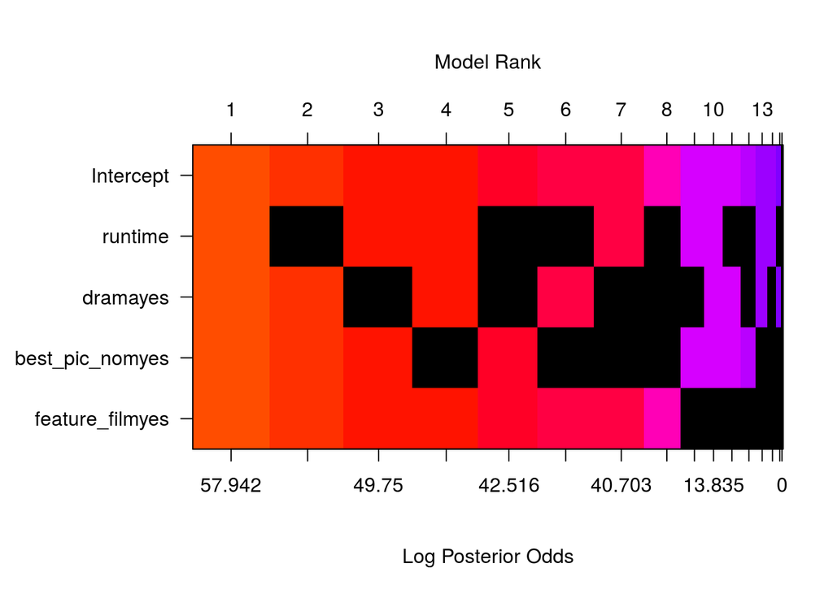

```r
image(mv_bas, rotate = F) #visualization
```

Log posterior odds indicate the log of Bayes factor. Black block indicates the respective predictor is excluded in the model. Therefore we see this results by Bayes factor are aligned with the results we have been seeing.

As the last step of diagnostic approach, we see the posterior distributions of the coefficients.

```r
mv_bma.coef = coef(mv_bas)
mv_bma.coef
```

```
##
##  Marginal Posterior Summaries of Coefficients:
##
##  Using  BMA
##
##  Based on the top  16 models
##                  post mean  post SD    post p(B != 0)
## Intercept         62.34769    0.71410    1.00000
## runtime            0.13712    0.04645    0.96525
## dramayes           7.32643    1.53431    0.99973
## best_pic_nomyes   19.96644    4.16504    0.99977
## feature_filmyes  -25.88281    2.57897    1.00000
```

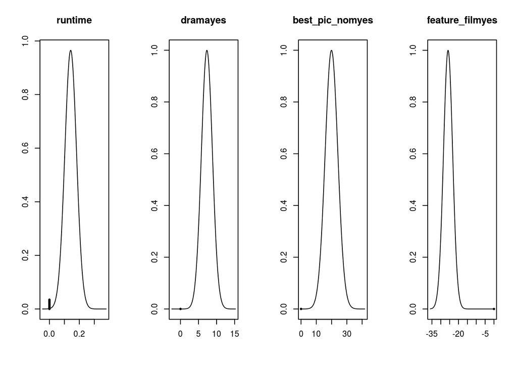

```r
par(mfrow = c(1,4))
plot(mv_bma.coef, subset = c(2:5))
```

All the coefficients have small mass at 0 which indicates that they should be included in the model.

With the above evaluation, we are good to move forward to prediction with the model `audience_score` ~ `feature_film` + `drama` + `runtime` + `best_pic_nom`.

## Part 5: Prediction

Now we are to actually use the model for predicting the audience score. I have picked Hidden Figures among the 2016 movies. The data for the predictors is obtained at [IMDB](https://www.imdb.com/title/tt4846340/?ref_=fn_al_tt_1), and the actual audience score from [Rotten Tomatoes](https://www.rottentomatoes.com/m/hidden_figures).

```r
hidden_figures <- data.frame(
  title = c ("Hidden Figures"),
  feature_film = c ("yes"),
  drama = c ("yes"),
  runtime = c (127),
  best_pic_nom = c ("yes")
)
hidden_figures
```

```
##            title feature_film drama runtime best_pic_nom
## 1 Hidden Figures          yes   yes     127          yes
```

```r
predict_01 <- predict(mv_bas, newdata = hidden_figures, se.fit = TRUE, interval = "predict", estimator = "BMA")
#to show results in a table
predict_01_sum <- data.frame(
  "Title" = c("Hidden Figures"), "Predicted audience score" = predict_01$Ybma, "Actual RT score" = c(93) )
predict_01_sum
```

```
##            Title Predicted.audience.score Actual.RT.score
## 1 Hidden Figures                 86.08166              93
```

I am certain this is a fairly good result, given other possible influential variables that are not in this dataset, which I am going to talk about in my conclusion section.

## Part 6: Conclusion

We can conclude that this process of modeling and prediction with Bayesian regression has worked sufficiently for the following reasons: * with the function which finds the best parsimonious model while presenting all other modeling and further elimination options * diagnostic approach looks thoroughly into the use of each predictor, by BIC, posterior probabilities, Bayes factor, and the distributions of coefficients  
It has answered the research question, the model to predict the audience score, with four predictors as `feature_film`, `drama`, `runtime`, `best_pic_nom` predictors, with which the test prediction outputs a fair result.  
As for discussion for developing better models, I would raise the following:  
* **Prior parameters**  
For this round of modeling, noninformative reference proior was applied. As we continue gathering data and modeling, we can have better priors.  
* **The choice of the response variable**  
In this dataset, choosing `audience_score` as a response variable is relevant. However, more objective measurement to predict that benefits filmmakers and the studio can be set.  
* **Timing factor**  
It would be interesting if we had the original dataset, from which per-movie summary becomes one observation in this dataset. And if such dataset had timestamps of when the audience score was given. Then we could learn, for example; 1) if there is any correlation between the time (between the time of the release and that of the audience scoring) and the score (being lower or higher), 2) if the time of the audience score being given has any impact on the score given, for instance whether any new awareness to some social issue or the cast relating to the movie influences scores (for example, cancel culture impacting or not).  
* **Credibility**  
Likewise, if we are to value the audience score as the response variable and if we had access to the detailed data, evaluating the credibility of score givers might be useful. So might another variable to indicate whether it was watched in the theater or via streamling be.  
Thank you for your attention. We look forward to providing you with more findings from data.

#### Appendix

There are 211 stuios in the data. Here is a view of where our studio and others are doing:

```r
t10_studios <- movies %>%
  filter((studio == "Paramount Pictures") | (studio == "Warner Bros. Pictures") | (studio == "Sony Pictures Home Entertainment") | (studio == "Universal Pictures")| (studio == "Warner Home Video") | (studio == "20th Century Fox") | (studio == "Miramax Films") | (studio == "MGM") | (studio == "Twentieth Century Fox Home Entertainment") | (studio == "IFC Films"))
```

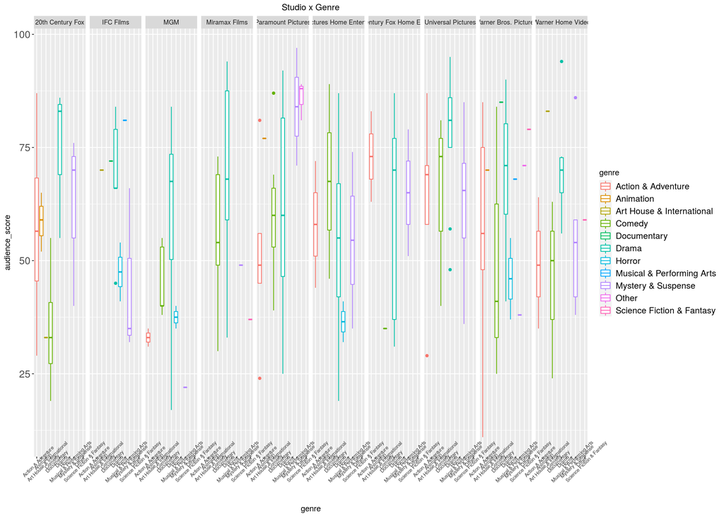

```r
ggplot(t10_studios, aes(x = genre, y = audience_score, color = genre)) +
    geom_boxplot()+
  theme(axis.text.x = element_text(angle = 45, size = 7)) +
  theme(axis.text.y = element_text(size = 14)) +
  ggtitle("Studio x Genre") +
    facet_grid(.~studio)+
  theme(plot.title = element_text(hjust = 0.5, size = 12)) +
  theme(legend.text = element_text(size = 12))
```